# Part 1- Loading the data and Pre-processing

```python
#Importing Relevant Packages

import numpy as np
import pandas as pd
%matplotlib inline
import matplotlib.pyplot as plt
plt.style.use('seaborn-whitegrid')
```

## The following csv files are downloaded from https://data.worldbank.org/indicator Which contains

## 1. The Military Expenditure of each country from 1960 in terms of current US dollars

## 2. The Total GDP of each country from 1960 in terms of current US dollars

## 3. The Population each country from 1960

```python
# Reading the CSV files into the notebook

ME = pd.read_csv("military_expenditure.csv",header=2,index_col=0) #Military Expenditure Dataset

GDP = pd.read_csv("GDP.csv",header=2,index_col = 0 ) #GDP Dataset

POP = pd.read_csv("POP.csv",header=2,index_col = 0 ) #Population Dataset
```

```python
POP.head()
```

| Country Name | Country Code | Indicator Name | Indicator Code | 1960 | 1961 | 1962 | 1963 | 1964 | 1965 | 1966 | ... | 2010 | 2011 | 2012 | 2013 | 2014 | 2015 | 2016 | 2017 | 2018 | Unnamed: 63 |
| --- | --- | --- | --- | --- | --- | --- | --- | --- | --- | --- | --- | --- | --- | --- | --- | --- | --- | --- | --- | --- | --- |
| Aruba | ABW | Population, total | SP.POP.TOTL | 54211.0 | 55438.0 | 56225.0 | 56695.0 | 57032.0 | 57360.0 | 57715.0 | ... | 101669.0 | 102046.0 | 102560.0 | 103159.0 | 103774.0 | 104341.0 | 104872.0 | 105366.0 | 105845.0 | NaN |
| Afghanistan | AFG | Population, total | SP.POP.TOTL | 8996973.0 | 9169410.0 | 9351441.0 | 9543205.0 | 9744781.0 | 9956320.0 | 10174836.0 | ... | 29185507.0 | 30117413.0 | 31161376.0 | 32269589.0 | 33370794.0 | 34413603.0 | 35383128.0 | 36296400.0 | 37172386.0 | NaN |
| Angola | AGO | Population, total | SP.POP.TOTL | 5454933.0 | 5531472.0 | 5608539.0 | 5679458.0 | 5735044.0 | 5770570.0 | 5781214.0 | ... | 23356246.0 | 24220661.0 | 25107931.0 | 26015780.0 | 26941779.0 | 27884381.0 | 28842484.0 | 29816748.0 | 30809762.0 | NaN |
| Albania | ALB | Population, total | SP.POP.TOTL | 1608800.0 | 1659800.0 | 1711319.0 | 1762621.0 | 1814135.0 | 1864791.0 | 1914573.0 | ... | 2913021.0 | 2905195.0 | 2900401.0 | 2895092.0 | 2889104.0 | 2880703.0 | 2876101.0 | 2873457.0 | 2866376.0 | NaN |
| Andorra | AND | Population, total | SP.POP.TOTL | 13411.0 | 14375.0 | 15370.0 | 16412.0 | 17469.0 | 18549.0 | 19647.0 | ... | 84449.0 | 83747.0 | 82427.0 | 80774.0 | 79213.0 | 78011.0 | 77297.0 | 77001.0 | 77006.0 | NaN |

5 rows × 63 columns

```python
ME.head()
```

| Country Name | Country Code | Indicator Name | Indicator Code | 1960 | 1961 | 1962 | 1963 | 1964 | 1965 | 1966 | ... | 2010 | 2011 | 2012 | 2013 | 2014 | 2015 | 2016 | 2017 | 2018 | Unnamed: 63 |
| --- | --- | --- | --- | --- | --- | --- | --- | --- | --- | --- | --- | --- | --- | --- | --- | --- | --- | --- | --- | --- | --- |
| Aruba | ABW | Military expenditure (current USD) | MS.MIL.XPND.CD | NaN | NaN | NaN | NaN | NaN | NaN | NaN | ... | NaN | NaN | NaN | NaN | NaN | NaN | NaN | NaN | NaN | NaN |
| Afghanistan | AFG | Military expenditure (current USD) | MS.MIL.XPND.CD | NaN | NaN | NaN | NaN | NaN | NaN | NaN | ... | 2.981469e+08 | 3.258070e+08 | 2.385834e+08 | 2.171941e+08 | 2.682271e+08 | 1.995186e+08 | 1.858783e+08 | 1.914071e+08 | 1.980863e+08 | NaN |
| Angola | AGO | Military expenditure (current USD) | MS.MIL.XPND.CD | NaN | NaN | NaN | NaN | NaN | NaN | NaN | ... | 3.500795e+09 | 3.639496e+09 | 4.144635e+09 | 6.090752e+09 | 6.841864e+09 | 3.608299e+09 | 2.764055e+09 | 3.062873e+09 | 1.983614e+09 | NaN |
| Albania | ALB | Military expenditure (current USD) | MS.MIL.XPND.CD | NaN | NaN | NaN | NaN | NaN | NaN | NaN | ... | 1.858932e+08 | 1.970068e+08 | 1.832047e+08 | 1.800155e+08 | 1.781204e+08 | 1.323507e+08 | 1.308532e+08 | 1.443827e+08 | 1.804887e+08 | NaN |
| Andorra | AND | Military expenditure (current USD) | MS.MIL.XPND.CD | NaN | NaN | NaN | NaN | NaN | NaN | NaN | ... | NaN | NaN | NaN | NaN | NaN | NaN | NaN | NaN | NaN | NaN |

5 rows × 63 columns

```python
GDP.head()
```

| Country Name | Country Code | Indicator Name | Indicator Code | 1960 | 1961 | 1962 | 1963 | 1964 | 1965 | 1966 | ... | 2010 | 2011 | 2012 | 2013 | 2014 | 2015 | 2016 | 2017 | 2018 | Unnamed: 63 |
| --- | --- | --- | --- | --- | --- | --- | --- | --- | --- | --- | --- | --- | --- | --- | --- | --- | --- | --- | --- | --- | --- |
| Aruba | ABW | GDP (current US$) | NY.GDP.MKTP.CD | NaN | NaN | NaN | NaN | NaN | NaN | NaN | ... | 2.390503e+09 | 2.549721e+09 | 2.534637e+09 | 2.581564e+09 | 2.649721e+09 | 2.691620e+09 | 2.646927e+09 | 2.700559e+09 | NaN | NaN |
| Afghanistan | AFG | GDP (current US$) | NY.GDP.MKTP.CD | 5.377778e+08 | 5.488889e+08 | 5.466667e+08 | 7.511112e+08 | 8.000000e+08 | 1.006667e+09 | 1.400000e+09 | ... | 1.585657e+10 | 1.780428e+10 | 2.000162e+10 | 2.056105e+10 | 2.048487e+10 | 1.990711e+10 | 1.936264e+10 | 2.019176e+10 | 1.936297e+10 | NaN |
| Angola | AGO | GDP (current US$) | NY.GDP.MKTP.CD | NaN | NaN | NaN | NaN | NaN | NaN | NaN | ... | 8.379950e+10 | 1.117897e+11 | 1.280529e+11 | 1.367099e+11 | 1.457122e+11 | 1.161936e+11 | 1.011239e+11 | 1.221238e+11 | 1.057510e+11 | NaN |
| Albania | ALB | GDP (current US$) | NY.GDP.MKTP.CD | NaN | NaN | NaN | NaN | NaN | NaN | NaN | ... | 1.192695e+10 | 1.289087e+10 | 1.231978e+10 | 1.277628e+10 | 1.322825e+10 | 1.138693e+10 | 1.186135e+10 | 1.302506e+10 | 1.505888e+10 | NaN |
| Andorra | AND | GDP (current US$) | NY.GDP.MKTP.CD | NaN | NaN | NaN | NaN | NaN | NaN | NaN | ... | 3.355695e+09 | 3.442063e+09 | 3.164615e+09 | 3.281585e+09 | 3.350736e+09 | 2.811489e+09 | 2.877312e+09 | 3.013387e+09 | 3.236544e+09 | NaN |

5 rows × 63 columns

```python
# Dropping the unnecessary columns

GDP.drop(['Country Code','Indicator Code','Indicator Name'],axis=1,inplace = True)
ME.drop(['Country Code','Indicator Code','Indicator Name'],axis=1,inplace = True)
POP.drop(['Country Code','Indicator Code','Indicator Name'],axis=1,inplace = True)
```

```python
# Saving the Countries and the Years to analyze in a list

Country_List= ['China','United States','United Kingdom', 'Russian Federation', 'Germany','France','Italy','Saudi Arabia','Korea, Rep.','Israel']
#My last name starts with I

Year_List = ['2010','2011','2012','2013','2014','2015','2016','2017','2018']
```

```python
# Transforming the Dataset to the relevant Countries and Years and saving it into a new dataframe

GDP1 = GDP.loc[Country_List][Year_List]
ME1 = ME.loc[Country_List][Year_List]
POP1 = POP.loc[Country_List][Year_List]
```

```python
# Making the Per Person Military Expenditure dataset, the Per Person GDP dataset and the Percentage of Military Expenditure to GDP dataset


PER_ME1 = ME1/POP1 # Per Person Military


PER_GDP1 = GDP1/POP1 # Per Person GDP

PERC_OF_ME1 = (ME1/GDP1) * 100 # Percentage of Military to GDP
```

```python
# Converting the GDP and Military Expenditure to Billion US dollar

GDP1 = GDP1/1000000000
ME1 = ME1/1000000000

GDP1
```

| Country Name | 2010 | 2011 | 2012 | 2013 | 2014 | 2015 | 2016 | 2017 | 2018 |
| --- | --- | --- | --- | --- | --- | --- | --- | --- | --- |
| China | 6087.164527 | 7551.500426 | 8532.230724 | 9570.405759 | 10438.529153 | 11015.542352 | 11137.945669 | 12143.491448 | 13608.151865 |
| United States | 14992.052727 | 15542.581104 | 16197.007349 | 16784.849190 | 17521.746534 | 18219.297584 | 18707.188235 | 19485.393853 | 20494.100000 |
| United Kingdom | 2452.899665 | 2634.895693 | 2676.605418 | 2753.565034 | 3034.729456 | 2896.420587 | 2659.238932 | 2637.866340 | 2825.207948 |
| Russian Federation | 1524.917468 | 2051.661732 | 2210.256977 | 2297.128039 | 2059.984158 | 1363.594370 | 1282.723881 | 1578.624061 | 1657.553766 |
| Germany | 3417.094563 | 3757.698281 | 3543.983909 | 3752.513503 | 3898.726504 | 3381.389339 | 3495.162856 | 3693.204332 | 3996.759291 |
| France | 2642.609549 | 2861.408170 | 2683.825225 | 2811.077726 | 2852.165761 | 2438.207896 | 2471.285607 | 2586.285407 | 2777.535239 |
| Italy | 2125.058244 | 2276.292405 | 2072.823157 | 2130.491321 | 2151.732868 | 1832.273033 | 1869.201702 | 1946.570340 | 2073.901989 |
| Saudi Arabia | 528.207200 | 671.238840 | 735.974843 | 746.647127 | 756.350347 | 654.269903 | 644.935541 | 688.586133 | 782.483467 |
| Korea, Rep. | 1094.499339 | 1202.463683 | 1222.807284 | 1305.604981 | 1411.333926 | 1382.764027 | 1414.804159 | 1530.750923 | 1619.423701 |
| Israel | 233.732926 | 261.716881 | 257.435002 | 292.917011 | 310.007879 | 300.470790 | 319.377924 | 353.268412 | 369.690436 |

```python
# Converting the population to Millions

POP1 = POP1/1000000
POP1
```

| Country Name | 2010 | 2011 | 2012 | 2013 | 2014 | 2015 | 2016 | 2017 | 2018 |
| --- | --- | --- | --- | --- | --- | --- | --- | --- | --- |
| China | 1337.705000 | 1344.130000 | 1350.695000 | 1357.380000 | 1364.270000 | 1371.220000 | 1378.665000 | 1386.395000 | 1392.730000 |
| United States | 309.326085 | 311.580009 | 313.874218 | 316.057727 | 318.386421 | 320.742673 | 323.071342 | 325.147121 | 327.167434 |
| United Kingdom | 62.766365 | 63.258918 | 63.700300 | 64.128226 | 64.613160 | 65.128861 | 65.595565 | 66.058859 | 66.488991 |
| Russian Federation | 142.849449 | 142.960868 | 143.201676 | 143.506911 | 143.819666 | 144.096870 | 144.342396 | 144.496740 | 144.478050 |
| Germany | 81.776930 | 80.274983 | 80.425823 | 80.645605 | 80.982500 | 81.686611 | 82.348669 | 82.657002 | 82.927922 |
| France | 65.027507 | 65.342780 | 65.659809 | 65.998687 | 66.316100 | 66.593366 | 66.859768 | 66.865144 | 66.987244 |
| Italy | 59.277417 | 59.379449 | 59.539717 | 60.233948 | 60.789140 | 60.730582 | 60.627498 | 60.536709 | 60.431283 |
| Saudi Arabia | 27.421461 | 28.267685 | 29.155187 | 30.052518 | 30.916994 | 31.717667 | 32.442572 | 33.099147 | 33.699947 |
| Korea, Rep. | 49.554112 | 49.936638 | 50.199853 | 50.428893 | 50.746659 | 51.014947 | 51.245707 | 51.466201 | 51.635256 |
| Israel | 7.623600 | 7.765800 | 7.910500 | 8.059500 | 8.215700 | 8.380100 | 8.546000 | 8.713300 | 8.883800 |

# Part 2- Visualization and Observations

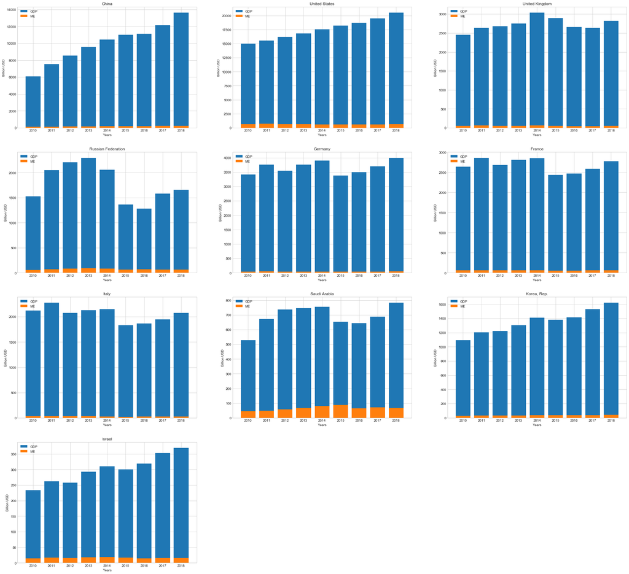

```python
#Plotting the GDP and Military Expenditure in the same bar graph for each year for each country

# This is to visualise the Military Expenditure relative to the GDP

i = 1
plt.figure(figsize=(32,30))

for rows in GDP1.index:

    plt.subplot(4,3,i)
    plt.bar(Year_List,GDP1.loc[rows])
    plt.bar(Year_List,ME1.loc[rows])
    plt.xlabel("Years")
    plt.ylabel("Billion USD")
    plt.legend(['GDP',"ME"],loc=2)
    plt.title(rows)
    i = i+1




plt.show()
```

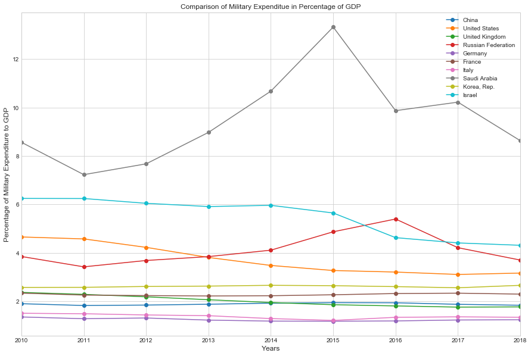

```python
#Plotting a line graph of the Percentage of Military Expenditure to GDP for each country


plt.figure(figsize=(15, 10))
for rows in PERC_OF_ME1.index:
    plt.plot(PERC_OF_ME1.loc[rows],marker = 'o')

plt.xlim(0,8)

plt.title('Comparison of Military Expenditue in Percentage of GDP', size = 'large')
plt.xlabel("Years",size = 'large')
plt.ylabel("Percentage of Military Expenditure to GDP", size = 'large')

plt.legend(Country_List)
plt.show()
```

## However Since the United States have a very high GDP, its absolute military expenditure will outshadow other countries. That fact isn't properly depicted by these bar plots and line graph

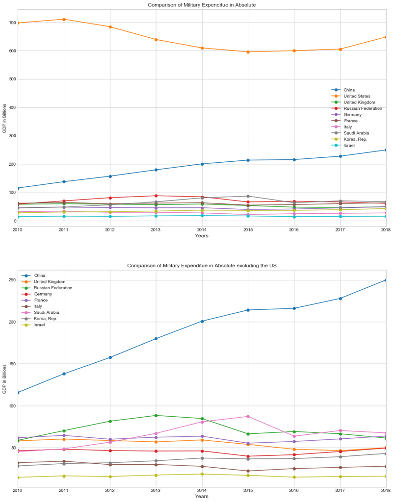

```python
#Plotting a line graph of the Military Expenditure of each year for each country in the same graph



plt.figure(figsize=(15, 20))
plt.subplot(211) # All Countries
for rows in ME1.index:
    plt.plot(ME1.loc[rows],marker = 'o')

plt.xlim(0,8)
plt.title('Comparison of Military Expenditue in Absolute', size = 'large')
plt.xlabel("Years",size = 'large')
plt.ylabel("GDP in Billions")
plt.legend(Country_List)



plt.subplot(212) # All Countries excluding the United States, in order to properly visualize other countries
for rows in ME1.index:
    if rows == 'United States':
        continue
    plt.plot(ME1.loc[rows],marker = 'o')

Country_List1 = Country_List.copy()
Country_List1.remove('United States')
plt.xlim(0,8)
plt.title('Comparison of Military Expenditue in Absolute excluding the US', size = 'large')
plt.xlabel("Years",size = 'large')
plt.ylabel("GDP in Billions")
plt.legend(Country_List1)

plt.show()
```

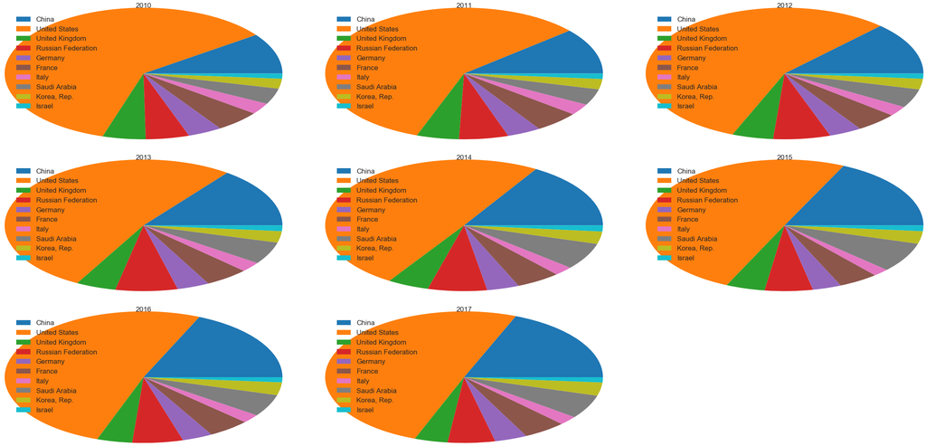

```python
#Plotting a pie chart of the Military Expenditure of each year to show each countries' relative percentage compared to each other

i = 1
j=0

plt.figure(figsize=(40,40))

for year in range (2010,2018):

    plt.subplot(6,3,i)
    plt.pie(ME1.iloc[:,j],radius = 1.3)

    plt.legend(Country_List,loc=2,fontsize = 'xx-large')
    plt.title(year,size='xx-large')
    i = i+1
    j = j+1
    year = year+1


plt.show()
```

## It can be seen that compared to other countries, China (Dark Blue) has the highest percentage increase in military spending throughout the years

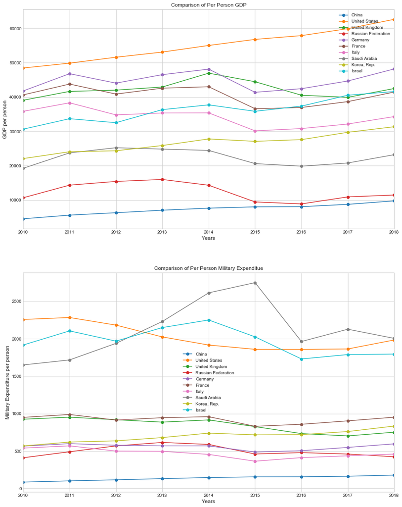

```python
plt.figure(figsize=(15, 20))
plt.axes()
plt.subplot(211)
for rows in PER_GDP1.index:
    plt.plot(PER_GDP1.loc[rows],marker = 'o')

plt.xlim(0,8)

plt.title('Comparison of Per Person GDP', size = 'large')
plt.xlabel("Years",size = 'large')
plt.ylabel("GDP per person", size = 'large')

plt.legend(Country_List)


plt.subplot(212)
for rows in PER_ME1.index:
    plt.plot(PER_ME1.loc[rows],marker = 'o')

plt.xlim(0,8)

plt.title('Comparison of Per Person Military Expenditue', size = 'large')
plt.xlabel("Years",size = 'large')
plt.ylabel("Military Expenditure per person", size = 'large')

plt.legend(Country_List)



plt.show()
```

## The relatively high Per Person Military Expenditure of the United States, Saudi Arabia and Israel shows that they are clearly expending more than average resources behind their Military

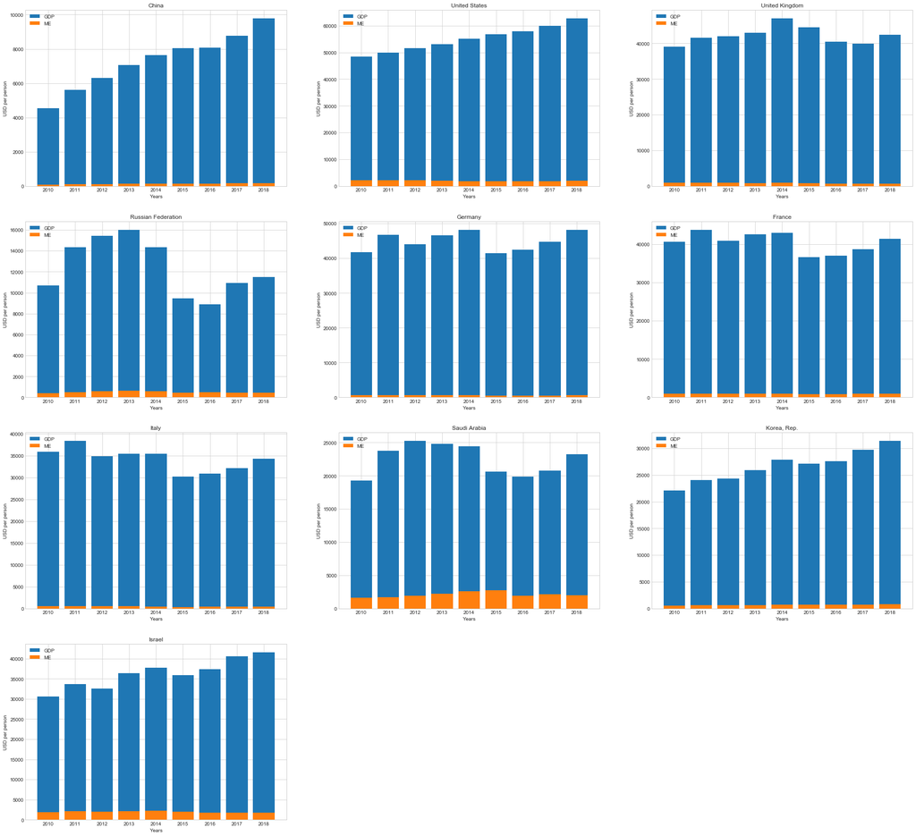

```python
i = 1
plt.figure(figsize=(32,30))

for rows in GDP1.index:

    plt.subplot(4,3,i)
    plt.bar(Year_List,PER_GDP1.loc[rows])
    plt.bar(Year_List,PER_ME1.loc[rows])
    plt.xlabel("Years")
    plt.ylabel("USD per person")
    plt.legend(['GDP',"ME"],loc=2)
    plt.title(rows)
    i = i+1
plt.show()
```

# **Part 3- Predictions**

## Countries' percentage Military Expenditure will stay at roughly the same level and its absolute value will only increase or decrease with the GDP.

## If a conflict arises, then the percentage of military expenditure to GDP will increase to fund the battle. Likewise, if the Middle East conflict resolves, then the percentage of military expenditure to GDP of Saudi Arabia and Israel will decrease and the budget will be allocated else where.

## Superpower like the United States will continue its high absolute military expenditure (even though the Military expenditure to GDP isn't significantly higher) to boast its military prowess across the globe unless significant reform occurs.

# Part 4- Conclusion

## All in all, unless there is a conflict, countries will have around the same low percentage of military expenditure to GDP in the future. Also superpowers will have a relatively high absolute military expenditure in order to showcase its power.